# Simulation-Based Power Analysis

Part 2: Within-subject design and linear modeling — Handout

Author

Affiliation

Filip Andras, David López-García & David Sánchez Casasola

Centro de Investigación Mente Cerebro y Comportamiento (CIMCYC), Universidad de Granada

Published

26 May 2026

# 1 From between- to within-subjects designs

Part 1 simulated a between-subjects design where 20 people were split into two groups of 10, each group seeing only one condition (high- or low-frequency words). That design throws away a lot of statistical power because the between-subjects variability is huge: people read at very different speeds, and that variability ends up in the noise term.

In a **within-subjects design** every subject sees both conditions. We collect two data points per person — one for high-frequency words, one for low-frequency words — and the contrast between conditions is computed *within* each subject. This removes the between-subjects variability from the comparison and dramatically increases power for the same number of subjects.

But there is a cost: the two observations from the same subject are no longer **independent**. They share whatever makes that subject fast or slow overall. The analysis has to account for this dependency, and so does the data-generating process when we simulate.

# 2 A first (incorrect) attempt

If we just write the same code as in Part 1, with 10 subjects each contributing two observations, we get a data frame that *looks* right:

```r
n        <- 10                                                  # number of subjects
freq_high <- round(rnorm(n, mean = 700, sd = 200))               # data for high freq
freq_low  <- round(rnorm(n, mean = 750, sd = 200))               # data for low freq

subj     <- rep(1:n, times = 2)                                 # subject vector
cond     <- factor(rep(c("freq_high", "freq_low"), each = n))     # condition vector
cond.cod <- ifelse(cond == "freq_high", -0.5, 0.5)               # effects coding

sim_dat <- data.frame(
  subj     = subj,
  cond     = cond,
  cond.cod = cond.cod,
  rt       = c(freq_high, freq_low)
)
sim_dat
```

```
   subj      cond cond.cod   rt
1     1 freq_high     -0.5  974
2     2 freq_high     -0.5  587
3     3 freq_high     -0.5  773
4     4 freq_high     -0.5  827
5     5 freq_high     -0.5  781
6     6 freq_high     -0.5  679
7     7 freq_high     -0.5 1002
8     8 freq_high     -0.5  681
9     9 freq_high     -0.5 1104
10   10 freq_high     -0.5  687
11    1  freq_low      0.5 1011
12    2  freq_low      0.5 1207
13    3  freq_low      0.5  472
14    4  freq_low      0.5  694
15    5  freq_low      0.5  723
16    6  freq_low      0.5  877
17    7  freq_low      0.5  693
18    8  freq_low      0.5  219
19    9  freq_low      0.5  262
20   10  freq_low      0.5 1014
```

We now have two observations per subject — one in each condition. But there is a problem: this code **assumes** the two observations from the same subject are independent, because `freq_high` and `freq_low` were generated from two separate `rnorm()` calls. The fact that they share a `subj` value is just bookkeeping; the generative process is still between-subjects in disguise.

# 3 Inducing dependency between observations

To simulate true within-subjects data we need each subject to have their own *true mean processing time*, which biases both of their observations in the same direction. Some subjects are systematically faster than 725 ms, others systematically slower. We capture this with a **by-subject adjustment to the intercept**, drawn from a normal distribution centred on zero:

```r
# generate adjustment to the intercept for each subject:
subject_adj <- round(rnorm(n, mean = 0, sd = 150))
subject_adj
```

```
 [1]  -46 -267  -26  182  284  -65  -39 -264   69  -96
```

A value of 0 means the subject’s true grand mean is exactly 725 ms. Positive values mean slower than average, negative values faster than average. Adding the adjustments to the grand mean gives each subject’s own baseline:

```r
round(725 + subject_adj)
```

```
 [1]  679  458  699  907 1009  660  686  461  794  629
```

Visually:

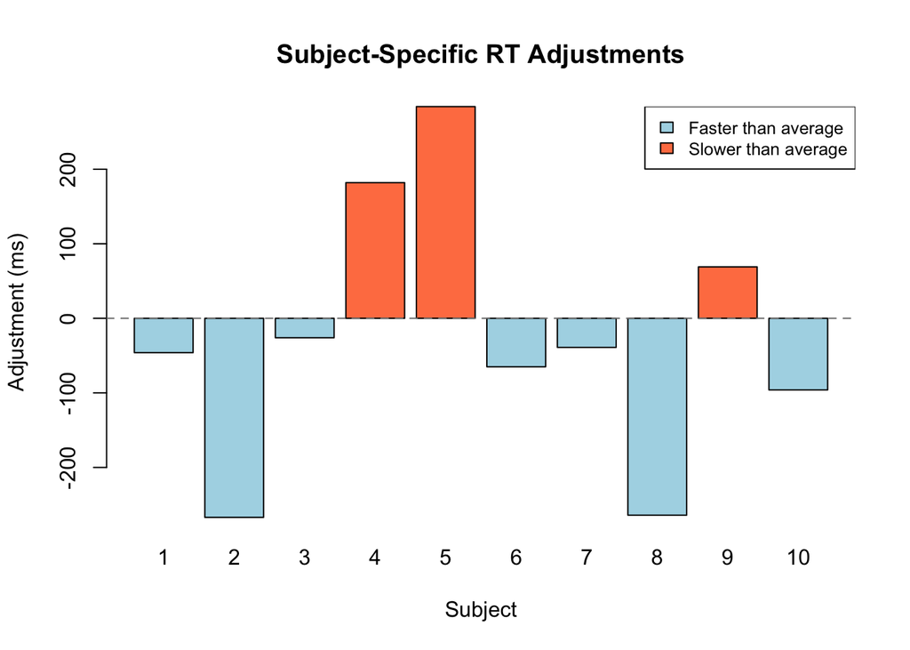

Figure 1: Subject-specific RT adjustments. Positive values are slower-than-average subjects; negative values are faster-than-average.

# 4 Generating dependent data

Now we replace the naive (independent) RT column with values that incorporate the subject-specific adjustment. The generative formula is:

$$rt_{ij} = \beta_0 + u_{0i} + \beta_1 \cdot \text{cond.cod}_{ij} + \epsilon_{ij}$$

with the following terms:

- $rt_{ij}$ = simulated response time for subject $i$ in condition $j$
- $\beta_0 = 725$ = grand mean (intercept)
- $u_{0i} \sim \text{Normal}(0, 150)$ = by-subject adjustment to the grand mean (the *random intercept*)
- $\beta_1 = 50$ = condition effect (slope)
- $\text{cond.cod}_{ij}$ = effects-coded condition (-0.5 / +0.5)
- $\epsilon_{ij} \sim \text{Normal}(0, 200)$ = residual error

Translated to code:

```r
rt <- round(725 +                             # grand mean
              rep(subject_adj, times = 2) +   # subject adjustments (repeated for both conditions)
              50 * cond.cod +                 # condition effect
              rnorm(2 * n, mean = 0, sd = 200)) # residual error

# replace the incorrect rt column in sim_dat with the dependent rt values:
sim_dat$rt <- rt
sim_dat
```

```
   subj      cond cond.cod   rt
1     1 freq_high     -0.5  745
2     2 freq_high     -0.5  574
3     3 freq_high     -0.5  881
4     4 freq_high     -0.5  760
5     5 freq_high     -0.5 1085
6     6 freq_high     -0.5  292
7     7 freq_high     -0.5  504
8     8 freq_high     -0.5  266
9     9 freq_high     -0.5  286
10   10 freq_high     -0.5  611
11    1  freq_low      0.5  745
12    2  freq_low      0.5  411
13    3  freq_low      0.5  876
14    4  freq_low      0.5  787
15    5  freq_low      0.5  760
16    6  freq_low      0.5  772
17    7  freq_low      0.5  549
18    8  freq_low      0.5  775
19    9  freq_low      0.5  733
20   10  freq_low      0.5  785
```

The `rep(subject_adj, times = 2)` is the key trick: the same subject adjustment is added to *both* observations from each subject, which is what creates the dependency.

## 4.1 What does this look like?

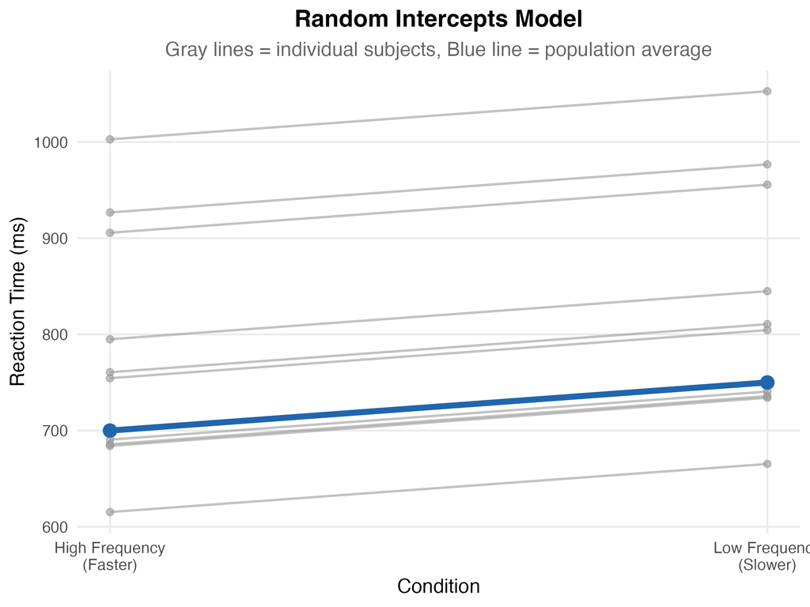

Figure 2: Random-intercepts model with 10 simulated subjects. Each gray line is one subject (with their own baseline RT, drawn from Normal(0, 150) around the grand mean). The blue line is the population average. Notice that the lines are **parallel** — every subject shows the same 50 ms effect, only their baseline differs.

Each gray line above is one simulated subject. The vertical spread reflects $u_{0i}$ — different baseline RTs. The lines are **parallel** because at this point in the course we still assume every subject shows the same 50 ms effect. Part 4 will relax that assumption.

# 5 Analyzing the data

There are two equivalent ways to analyse this within-subjects design. The paired t-test is the classical approach; the linear mixed-effects model (LMM) is the modern generalisable one. Click between the tabs below to compare:

**Paired t-test**

```r
freq_low_vals  <- sim_dat$rt[sim_dat$cond == "freq_low"]
freq_high_vals <- sim_dat$rt[sim_dat$cond == "freq_high"]
t.test(freq_low_vals, freq_high_vals, paired = TRUE)
```

```
    Paired t-test

data:  freq_low_vals and freq_high_vals
t = 1.3357, df = 9, p-value = 0.2144
alternative hypothesis: true mean difference is not equal to 0
95 percent confidence interval:
 -82.47108 320.27108
sample estimates:
mean difference
          118.9
```

The paired t-test directly subtracts each subject’s two observations, removing the by-subject baseline before testing.

**Linear mixed-effects model**

```r
m <- lmer(rt ~ cond.cod + (1 | subj), sim_dat,
          control = lmerControl(calc.derivs = FALSE))
summary(m)
```

```
Linear mixed model fit by REML. t-tests use Satterthwaite's method ['lmerModLmerTest']
Formula: rt ~ cond.cod + (1 | subj)
   Data: sim_dat
Control: lmerControl(calc.derivs = FALSE)

REML criterion at convergence: 249

Scaled residuals:
    Min      1Q  Median      3Q     Max
-1.4945 -0.3996  0.1395  0.4731  2.0849

Random effects:
 Groups   Name        Variance Std.Dev.
 subj     (Intercept)  7142     84.51
 Residual             39620    199.05
Number of obs: 20, groups:  subj, 10

Fixed effects:
            Estimate Std. Error     df t value    Pr(>|t|)
(Intercept)   659.85      51.92   9.00  12.710 0.000000471 ***
cond.cod      118.90      89.02   9.00   1.336       0.214
---
Signif. codes:  0 '***' 0.001 '**' 0.01 '*' 0.05 '.' 0.1 ' ' 1

Correlation of Fixed Effects:
         (Intr)
cond.cod 0.000
```

The `(1 | subj)` term tells the model: “each subject has their own intercept, drawn from a normal distribution centred on the grand mean”. This is exactly the data-generating process we used above.

The t-value for the `cond.cod` coefficient matches the paired t-test t-value — **the two approaches are mathematically equivalent** for this simple case.

The mixed-effects formulation matters for the rest of the course: it scales naturally to designs with multiple trials per condition per subject, by-item variability, correlated random effects, and so on. The paired t-test does not.

# 6 Comparing power: paired t-test vs. mixed model

We repeat the simulation 1000 times and compute power both ways. The result confirms that the two approaches give essentially identical power estimates:

```r
nsim <- 1000
pvals_paired <- pvals_lmer <- rep(NA, nsim)

for (i in 1:nsim) {
  subject_adj <- round(rnorm(n, mean = 0, sd = 150))
  sim_dat$rt  <- round(725 +
                         rep(subject_adj, 2) +
                         50 * cond.cod +
                         rnorm(2 * n, 0, 200))

  # paired t-test:
  freq_low_vals    <- sim_dat$rt[sim_dat$cond == "freq_low"]
  freq_high_vals   <- sim_dat$rt[sim_dat$cond == "freq_high"]
  pvals_paired[i] <- t.test(freq_low_vals, freq_high_vals, paired = TRUE)$p.value

  # linear mixed-effects model:
  m_temp        <- lmer(rt ~ cond.cod + (1 | subj), sim_dat,
                        control = lmerControl(calc.derivs = FALSE))
  pvals_lmer[i] <- summary(m_temp)$coefficients[2, 5]
}

mean(pvals_paired < 0.05) # paired t-test
```

```
[1] 0.074
```

```r
mean(pvals_lmer   < 0.05) # linear mixed-effects model
```

```
[1] 0.077
```

# 7 Wrapping it in a function

For all subsequent simulations we will reuse a clean data-generation function:

```r
withinsubj_simdat <- function(n = 10,            # number of subjects
                              b0 = 725,          # grand mean (intercept)
                              b1 = 50,           # condition effect (slope)
                              sigma_u0 = 150,    # SD of random intercepts
                              sigma = 200) {     # residual SD
  u0       <- round(rnorm(n, mean = 0, sd = sigma_u0)) # subject adjustments
  cond.cod <- rep(c(-0.5, 0.5), each = n)              # effects-coded condition
  subj     <- rep(1:n, times = 2)                      # subject vector

  # generate dependent response times:
  rt <- round(b0 +
                rep(u0, times = 2) +
                b1 * cond.cod +
                rnorm(2 * n, mean = 0, sd = sigma))

  data.frame(subj = subj, cond.cod = cond.cod, rt = rt)
}
```

# 8 Parameter recovery

Just like in Part 1.2, we want to check whether the model can recover the true parameter values under repeated sampling. Now we have **four** parameters to recover: the intercept ($\beta_0 = 725$), the slope ($\beta_1 = 50$), the SD of the random intercepts ($\sigma_{u0} = 150$), and the residual SD ($\sigma = 200$).

The only thing that changes between the two tabs below is the number of subjects (`n = 10` vs `n = 100`). Compare the histograms to see how parameter recovery improves with more data.

**n = 10 subjects**

```r
nsim   <- 1000
params <- matrix(rep(NA, nsim * 4), ncol = 4)

for (i in 1:nsim) {
  sim_dat <- withinsubj_simdat()
  m       <- lmer(rt ~ cond.cod + (1 | subj), sim_dat,
                  control = lmerControl(calc.derivs = FALSE))
  params[i, 1] <- summary(m)$coefficients[1, 1]              # intercept
  params[i, 2] <- summary(m)$coefficients[2, 1]              # slope
  params[i, 3] <- attr(VarCorr(m)$subj, "stddev")            # sd random intercepts
  params[i, 4] <- attr(VarCorr(m), "sc")                     # residual SD
}
```

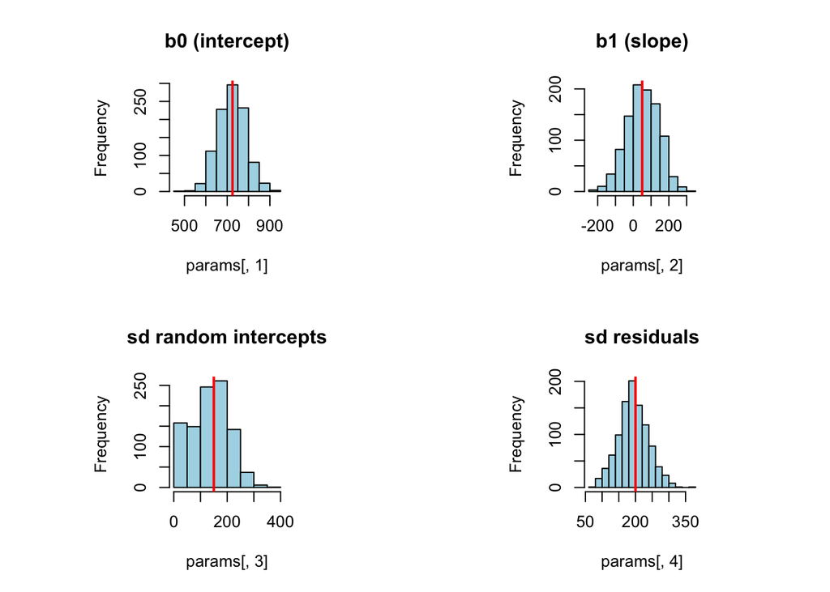

Figure 3: Parameter recovery with n = 10 subjects, 1000 simulations. Red lines mark the true generating values.

**n = 100 subjects**

```r
nsim   <- 1000
params <- matrix(rep(NA, nsim * 4), ncol = 4)

for (i in 1:nsim) {
  sim_dat <- withinsubj_simdat(n = 100) # this is what we change
  m       <- lmer(rt ~ cond.cod + (1 | subj), sim_dat,
                  control = lmerControl(calc.derivs = FALSE))
  params[i, 1] <- summary(m)$coefficients[1, 1]
  params[i, 2] <- summary(m)$coefficients[2, 1]
  params[i, 3] <- attr(VarCorr(m)$subj, "stddev")
  params[i, 4] <- attr(VarCorr(m), "sc")
}
```

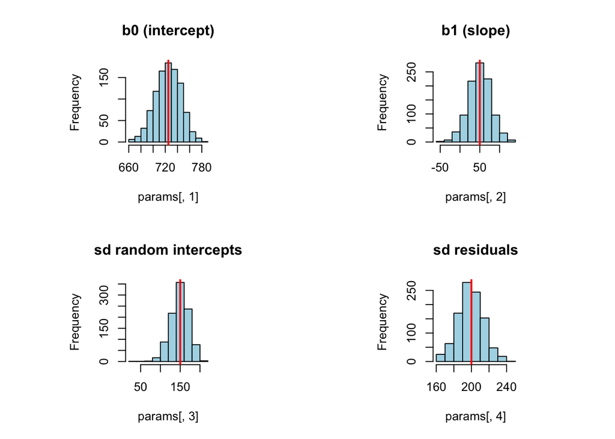

Figure 4: Parameter recovery with n = 100 subjects, 1000 simulations. The estimates now cluster tightly around the true values.

With n = 100 subjects the estimates are **much narrower and more precise**, and the zero-variance pathology disappears.

This is the parameter-recovery payoff: simulation tells you in advance whether your design has the information needed to estimate the parameters of interest — separately from whether it has enough power.

# 9 Summary and next step

So far we have:

- Recognised that within-subjects observations are dependent and need a random intercept to model that dependency.
- Compared the paired t-test and the random-intercept linear mixed-effects model and found them equivalent for the simplest case.
- Used parameter recovery to diagnose the failure mode at n = 10 (zero-variance estimates of the random intercept) and the resolution at n = 100.

So far we have simulated only **one observation per condition per subject**:

```r
head(xtabs(~ subj + cond.cod, sim_dat))
```

```
    cond.cod
subj -0.5 0.5
   1    1   1
   2    1   1
   3    1   1
   4    1   1
   5    1   1
   6    1   1
```

The next part of the course generalises to **multiple repeated measures per condition per subject** — the typical case in cognitive experiments, where each subject contributes dozens of trials per condition.